# iLab 4 - Assesment

Eric Stevens

12/13/2018

## Logistics

```r
library(tidyverse)
library(moderndive)
library(broom)
library(infer)
library(multcomp) # for post-hoc tests
library(ggbeeswarm)
library(car) # for Anova
library(phia) # for post-hoc tests
library(skimr)
select <- dplyr::select # deals with the namespace conflict
```

## Data

```r
or_vitd <- read_csv("http://bit.ly/conj620-orvitdcsv",
                    col_types = cols(
                      season = col_factor(levels = NULL),
                      patient_type = col_factor(levels = NULL),
                      region = col_factor(levels = NULL)))
```

## EDA

First lets have a glimpse of the raw data.

```r
glimpse(or_vitd)
```

```
## Observations: 533
## Variables: 6
## $ patient_type <fct> CASE, CASE, CASE, CASE, CASE, CASE, CASE, CASE, C...
## $ gender       <chr> "FEMALE", "FEMALE", "FEMALE", "FEMALE", "MALE", "...
## $ season       <fct> winter, winter, winter, winter, winter, winter, w...
## $ region       <fct> NW, NW, NW, NW, NW, NW, NW, NW, NW, NW, NW, NW, N...
## $ age          <int> 9, 9, 9, 9, 9, 9, 9, 9, 9, 9, 9, 9, 9, 9, 9, 10, ...
## $ vitamin_d    <dbl> 24, 23, 24, 28, 11, 19, 22, 24, 28, 30, 31, 37, 5...
```

```r
or_vitd
```

```
## # A tibble: 533 x 6
##    patient_type gender season region   age vitamin_d
##    <fct>        <chr>  <fct>  <fct>  <int>     <dbl>
##  1 CASE         FEMALE winter NW         9        24
##  2 CASE         FEMALE winter NW         9        23
##  3 CASE         FEMALE winter NW         9        24
##  4 CASE         FEMALE winter NW         9        28
##  5 CASE         MALE   winter NW         9        11
##  6 CASE         MALE   winter NW         9        19
##  7 CASE         MALE   winter NW         9        22
##  8 CASE         MALE   winter NW         9        24
##  9 CASE         MALE   winter NW         9        28
## 10 CASE         MALE   winter NW         9        30
## # ... with 523 more rows
```

We first make a visualization of the seperated categories, we then use group to split the two in the dataframe and push it through skim to to see the numbers of each group, their means, and standard deviations of them individually.

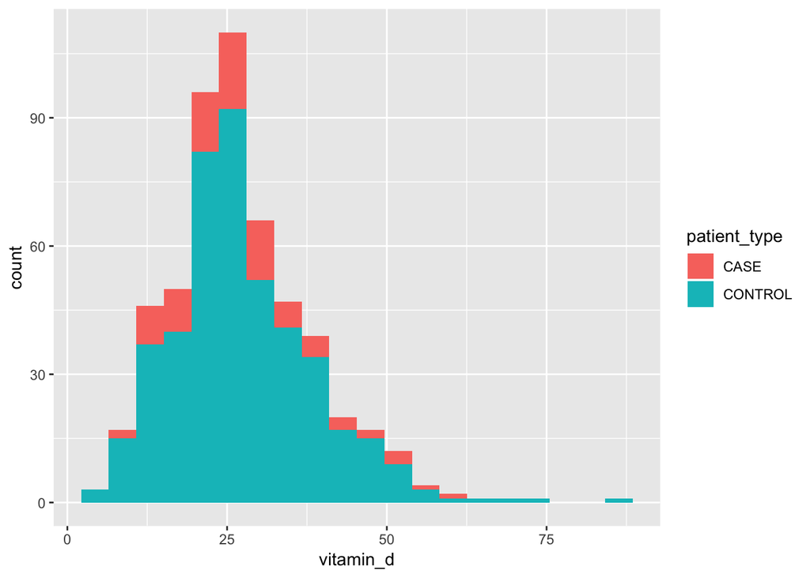

```r
ggplot(data=or_vitd, aes(vitamin_d, fill=patient_type)) +
  geom_histogram(bins = 20)
```

```r
or_vitd %>% group_by(patient_type) %>% skim()
```

```
## Skim summary statistics
##  n obs: 533
##  n variables: 6
##  group variables: patient_type
##
## ── Variable type:character ─────────────────────────────────────
##  patient_type variable missing complete   n min max empty n_unique
##          CASE   gender       0       88  88   4   6     0        2
##       CONTROL   gender       0      445 445   4   6     0        2
##
## ── Variable type:factor ────────────────────────────────────────
##  patient_type variable missing complete   n n_unique
##          CASE   region       0       88  88        4
##          CASE   season       0       88  88        2
##       CONTROL   region       0      445 445        4
##       CONTROL   season       0      445 445        2
##                        top_counts ordered
##      NW: 52, SW: 25, SE: 8, NE: 3   FALSE
##           win: 62, sum: 26, NA: 0   FALSE
##  NW: 301, SW: 115, SE: 18, NE: 11   FALSE
##         win: 291, sum: 154, NA: 0   FALSE
##
## ── Variable type:integer ───────────────────────────────────────
##  patient_type variable missing complete   n  mean   sd p0 p25 p50 p75 p100
##          CASE      age       5       83  88 12.43 3.51  9   9  11  15   20
##       CONTROL      age       0      445 445 14.56 3.39  8  12  15  17   20
##      hist
##  ▇▁▂▁▂▂▁▁
##  ▃▆▂▆▅▇▃▆
##
## ── Variable type:numeric ───────────────────────────────────────
##  patient_type  variable missing complete   n  mean    sd p0 p25 p50  p75
##          CASE vitamin_d       0       88  88 27.03 10.93  8  20  25 32
##       CONTROL vitamin_d       0      445 445 27.59 11.18  5  21  26 33.1
##  p100     hist
##  58.9 ▃▅▇▇▂▁▁▁
##  87   ▃▇▇▃▁▁▁▁
```

Above we can confirm that there are 88 IME cases labeled in the summary as CAS, whis is short for CASE whis is there factorial designation in the data. There are also 445 CON, short for CONTROL. The CASE group has a mean of 27.03 and a standard deviation of 10.93. The CONTROL group has a mean of 27.59 and a standard deviation of 11.18.

## Comparing Means

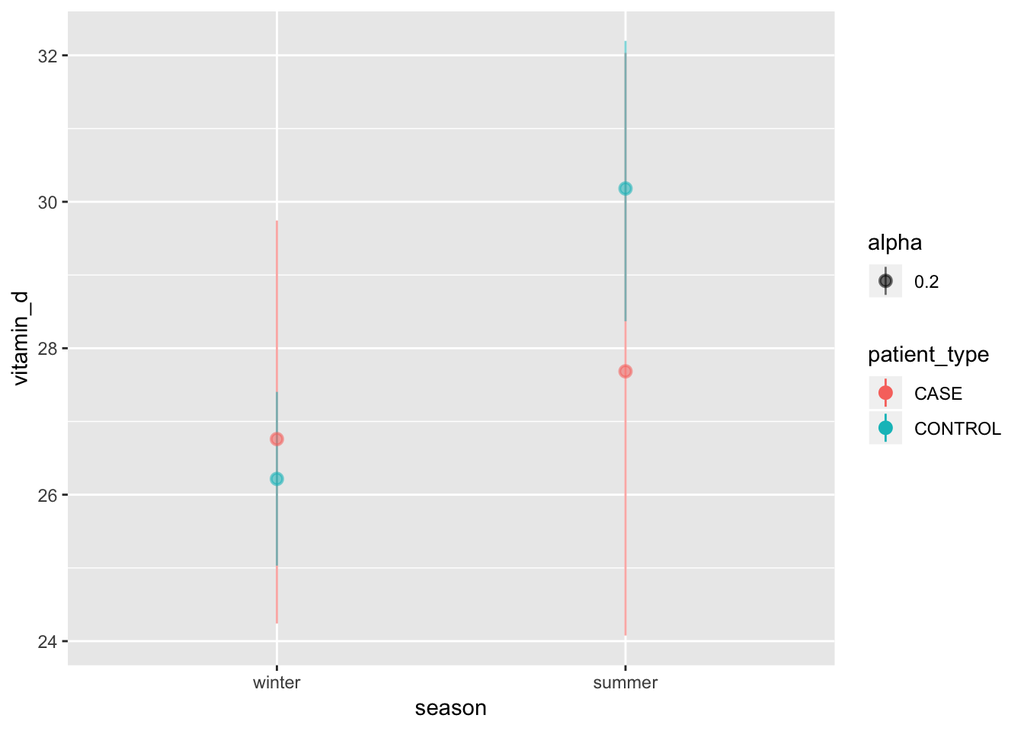

```r
ggplot(or_vitd, aes(x=season, y = vitamin_d, color=patient_type,alpha = .2)) +
  stat_summary(fun.data = mean_cl_boot)
```

The null hypothisis is that the case group and control group have the same mean. The alternavive hypothisis is that they differ in sensitivity to season.

## Two Way Ancova

```r
# patient only
vitd_patient <- lm(vitamin_d ~ patient_type + season, data = or_vitd)
anova(vitd_patient)
```

```
## Analysis of Variance Table
##
## Response: vitamin_d
##               Df Sum Sq Mean Sq F value    Pr(>F)
## patient_type   1     23   22.64  0.1861 0.6663360
## season         1   1456 1455.90 11.9681 0.0005848 ***
## Residuals    530  64474  121.65
## ---
## Signif. codes:  0 '***' 0.001 '**' 0.01 '*' 0.05 '.' 0.1 ' ' 1
```

```r
# season only
vitd_season <- lm(vitamin_d ~ season + patient_type, data = or_vitd)
anova(vitd_season)
```

```
## Analysis of Variance Table
##
## Response: vitamin_d
##               Df Sum Sq Mean Sq F value    Pr(>F)
## season         1   1468 1468.05 12.0680 0.0005549 ***
## patient_type   1     10   10.49  0.0862 0.7691601
## Residuals    530  64474  121.65
## ---
## Signif. codes:  0 '***' 0.001 '**' 0.01 '*' 0.05 '.' 0.1 ' ' 1
```

```r
# patient + season
vitd_patient <- lm(vitamin_d ~ patient_type + season, data = or_vitd)
anova(vitd_patient)
```

```
## Analysis of Variance Table
##
## Response: vitamin_d
##               Df Sum Sq Mean Sq F value    Pr(>F)
## patient_type   1     23   22.64  0.1861 0.6663360
## season         1   1456 1455.90 11.9681 0.0005848 ***
## Residuals    530  64474  121.65
## ---
## Signif. codes:  0 '***' 0.001 '**' 0.01 '*' 0.05 '.' 0.1 ' ' 1
```

```r
# season + patient
vitd_season <- lm(vitamin_d ~ season + patient_type, data = or_vitd)
anova(vitd_season)
```

```
## Analysis of Variance Table
##
## Response: vitamin_d
##               Df Sum Sq Mean Sq F value    Pr(>F)
## season         1   1468 1468.05 12.0680 0.0005549 ***
## patient_type   1     10   10.49  0.0862 0.7691601
## Residuals    530  64474  121.65
## ---
## Signif. codes:  0 '***' 0.001 '**' 0.01 '*' 0.05 '.' 0.1 ' ' 1
```

## Two Way ANCOVA with Type II SS

```r
vitd_add <- lm(vitamin_d ~ season + patient_type, data = or_vitd)
Anova(vitd_add, type = 2)
```

```
## Anova Table (Type II tests)
##
## Response: vitamin_d
##              Sum Sq  Df F value    Pr(>F)
## season         1456   1 11.9681 0.0005848 ***
## patient_type     10   1  0.0862 0.7691601
## Residuals     64474 530
## ---
## Signif. codes:  0 '***' 0.001 '**' 0.01 '*' 0.05 '.' 0.1 ' ' 1
```

```r
vitd_add <- lm(vitamin_d ~ patient_type + season, data = or_vitd)
Anova(vitd_add, type = 2)
```

```
## Anova Table (Type II tests)
##
## Response: vitamin_d
##              Sum Sq  Df F value    Pr(>F)
## patient_type     10   1  0.0862 0.7691601
## season         1456   1 11.9681 0.0005848 ***
## Residuals     64474 530
## ---
## Signif. codes:  0 '***' 0.001 '**' 0.01 '*' 0.05 '.' 0.1 ' ' 1
```

They are the same.

We can reject the hypothesis that season has no effect on the means.

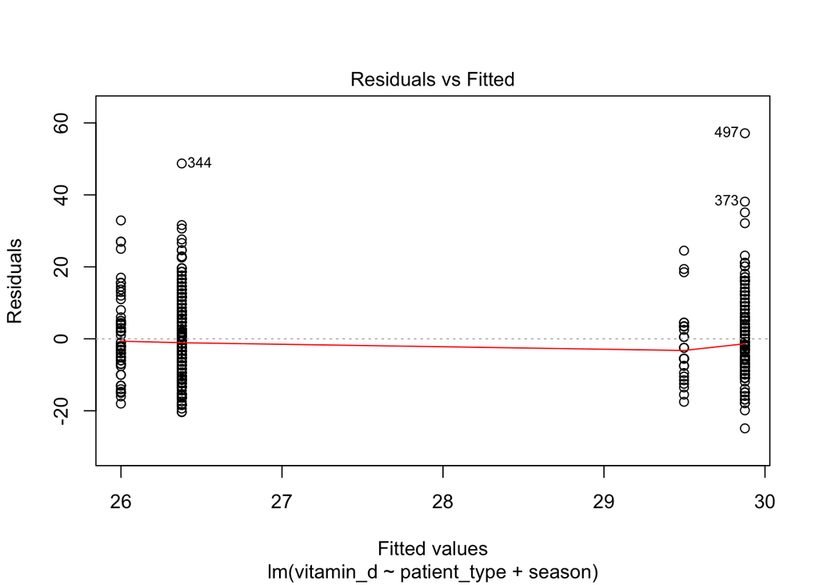

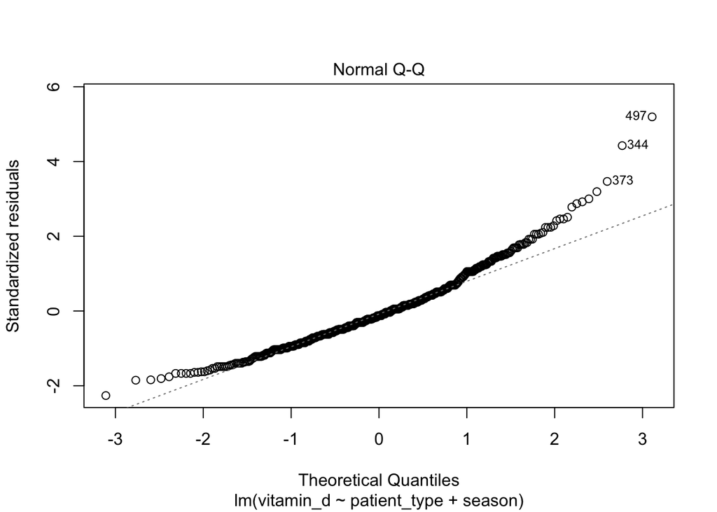

```r
library(phia)

plot(vitd_add, 1:2)
```

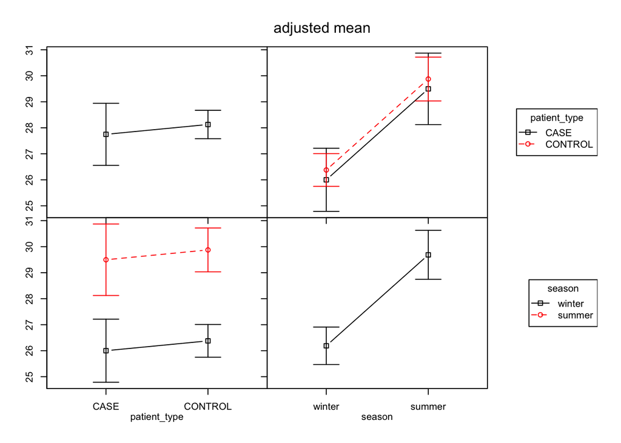

```r
vitd_add_means <- interactionMeans(vitd_add)
plot(vitd_add_means)
```

This section should have had the title on it. It is actually the Anova with the interaction

## Two-way ANOVA with Type II SS

```r
vitd_times <- lm(vitamin_d ~ season * patient_type, data = or_vitd)
Anova(vitd_times, type = 2)
```

```
## Anova Table (Type II tests)
##
## Response: vitamin_d
##                     Sum Sq  Df F value    Pr(>F)
## season                1456   1 11.9721 0.0005836 ***
## patient_type            10   1  0.0862 0.7691226
## season:patient_type    143   1  1.1782 0.2782219
## Residuals            64330 529
## ---
## Signif. codes:  0 '***' 0.001 '**' 0.01 '*' 0.05 '.' 0.1 ' ' 1
```

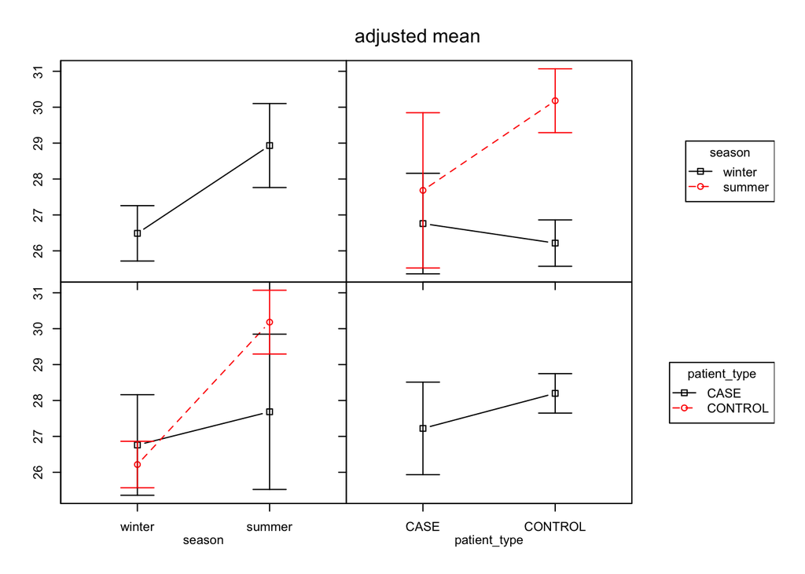

```r
vitd_times_means <- interactionMeans(vitd_times)
plot(vitd_times_means)

#testInteractions(lm_model, pairwise = "variable_name", adjustment = "p.adjust.method")
```

Here I had ran out of time to complete the initial assignment. The following I am completing for the assesment.

In the ANOVA above the table shows that the only signifigant factor was the season. This effect is visable in the slope difference in the graph. In this graph we have lines of different slopes. That is because in this graph we are looking at an interaction which allows for the lines to take on different slops. These lines track the effects of the predictor variables individually, instead of just showing the main effect.

## Final two-way ANOVA

```r
vitd_times <- lm(vitamin_d ~ season * region, data = or_vitd)
Anova(vitd_times, type = 2)
```

```
## Anova Table (Type II tests)
##
## Response: vitamin_d
##               Sum Sq  Df F value    Pr(>F)
## season          1461   1 11.9157 0.0006015 ***
## region            59   3  0.1615 0.9222116
## season:region     60   3  0.1631 0.9212087
## Residuals      64365 525
## ---
## Signif. codes:  0 '***' 0.001 '**' 0.01 '*' 0.05 '.' 0.1 ' ' 1
```

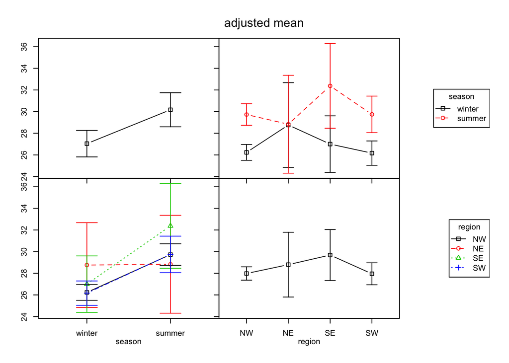

```r
vitd_times_means <- interactionMeans(vitd_times)
plot(vitd_times_means)

#testInteractions(lm_model, pairwise = "variable_name", adjustment = "p.adjust.method")
```

Again we see that the season is the signifigant predictor. North and south seem to be less important than east and west. Also it appears that the in the NE season does not seem to have an effect.

```r
testInteractions(vitd_times, pairwise = "region", adjustment = "bonferroni")
```

```
## F Test:
## P-value adjustment method: bonferroni
##              Value  Df Sum of Sq      F Pr(>F)
## NW-NE     -0.81633   1         9 0.0715      1
## NW-SE     -1.70591   1        60 0.4919      1
## NW-SW      0.02702   1         0 0.0005      1
## NE-SE     -0.88958   1         7 0.0547      1
## NE-SW      0.84335   1         9 0.0713      1
## SE-SW      1.73293   1        56 0.4576      1
## Residuals          525     64365
```

```r
testInteractions(vitd_times, pairwise = "region", fixed = "season", adjustment = "bonferroni")
```

```
## F Test:
## P-value adjustment method: bonferroni
##                  Value  Df Sum of Sq      F Pr(>F)
## NW-NE : winter -2.5286   1        49 0.4032      1
## NW-SE : winter -0.7661   1        10 0.0799      1
## NW-SW : winter  0.0690   1         0 0.0026      1
## NE-SE : winter  1.7625   1        17 0.1403      1
## NE-SW : winter  2.5976   1        50 0.4067      1
## SE-SW : winter  0.8351   1        11 0.0864      1
## NW-NE : summer  0.8959   1         5 0.0375      1
## NW-SE : summer -2.6457   1        53 0.4289      1
## NW-SW : summer -0.0149   1         0 0.0001      1
## NE-SE : summer -3.5417   1        43 0.3508      1
## NE-SW : summer -0.9109   1         4 0.0356      1
## SE-SW : summer  2.6308   1        47 0.3808      1
## Residuals              525     64365
```

Above two blocks taken form solution.